# The Geography of Going Hungry: Food Insecurity Across Western North Carolina

Western North Carolina is a region of striking contrasts. Its mountains, forests, and rivers draw visitors from across the country, yet beneath that natural beauty and abundance lies a persistent and uneven struggle — about one in four people across the region cannot count on their next meal.

Food insecurity is the condition of not having reliable access to enough affordable, nutritious food. The eighteen counties of the Western North Carolina Health Network reported food insecurity rates ranging from 16.6% to 41.7% in 2024, with a regional average of 27.4% — well above national benchmarks.

The map below shows the approximate percentage of people in each county who face food insecurity.

[interactive chart not shown]

## A Closer Look at the Counties with the Highest Need

Food insecurity does not affect all communities equally. The three counties with the highest food insecurity rates in the region are examined below. Each table compares that county’s key socioeconomic indicators to the 18-county regional average. Red-orange values indicate the county is worse than average on that indicator — a signal of compounding vulnerability. Teal values indicate the county performs better than the regional average on that measure.

What emerges is not a single story — the drivers of food insecurity differ meaningfully from county to county.

**Rutherford County**

Food insecurity: **41.7%** vs. regional avg 27.4%

| Indicator | Rutherford | Regional avg | Difference |  |
| --- | --- | --- | --- | --- |
| Poverty rate | 17.6% | 14.1% | +24.7% | ↑ |
| Median household income | $49,771 | $57,301 | -13.1% | ↓ |
| Rural population | 67.8% | 76.9% | -11.8% | ↓ |
| Renters with no vehicle | 10.8% | 13.7% | -21.3% | ↓ |
| SNAP households | 7,012 | 3,491 | +100.9% | ↑ |
| Bachelor’s degree or higher | 20.7% | 26.2% | -20.9% | ↓ |

Source: Western North Carolina Health Network. (2025). 18-County Data Workbook.

**Jackson County**

Food insecurity: **35%** vs. regional avg 27.4%

| Indicator | Jackson | Regional avg | Difference |  |
| --- | --- | --- | --- | --- |
| Poverty rate | 19.3% | 14.1% | +36.7% | ↑ |
| Median household income | $53,479 | $57,301 | -6.7% | ↓ |
| Rural population | 66.7% | 76.9% | -13.3% | ↓ |
| Renters with no vehicle | 6.7% | 13.7% | -50.9% | ↓ |
| SNAP households | 2,292 | 3,491 | -34.3% | ↓ |
| Bachelor’s degree or higher | 30% | 26.2% | +14.6% | ↑ |

Source: Western North Carolina Health Network. (2025). 18-County Data Workbook.

**Haywood County**

Food insecurity: **30%** vs. regional avg 27.4%

| Indicator | Haywood | Regional avg | Difference |  |
| --- | --- | --- | --- | --- |
| Poverty rate | 11.3% | 14.1% | -20% | ↓ |
| Median household income | $61,001 | $57,301 | +6.5% | ↑ |
| Rural population | 46.9% | 76.9% | -39% | ↓ |
| Renters with no vehicle | 8.3% | 13.7% | -39.2% | ↓ |
| SNAP households | 4,548 | 3,491 | +30.3% | ↑ |
| Bachelor’s degree or higher | 29.4% | 26.2% | +12.3% | ↑ |

Source: Western North Carolina Health Network. (2025). 18-County Data Workbook.

## Rutherford County: A Case Study in Rural Food Insecurity

### Population and Poverty by Census Tract

County-level statistics tell only part of the story. Zooming in to the census tract level reveals where within Rutherford County need is most concentrated — and where it may be most visible to service providers, or most hidden from them. The maps below show population density and poverty rate side by side across Rutherford’s census tracts. Darker colors indicate higher values. Areas of high poverty do not always coincide with areas of high population density — a pattern that has real consequences for where food assistance resources are located and who can realistically reach them.

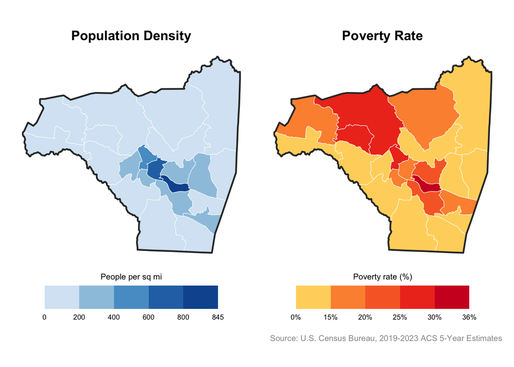

### Food Pantry Access: Who Can Get There?

The map below shows the locations of food pantries across Rutherford County alongside drive time isochrones, the areas reachable within 10 and 20 minutes by car from any pantry. The areas that fall outside both rings represent communities where pantry access requires a significant investment of time and transportation. The gaps on this map are not empty space. They are where the need is hardest to meet.

[interactive chart not shown]

## A Note on the Data

Food insecurity rates are drawn from the 2025 18-County Health Network Data Workbook, using the Feeding America methodology.

Socioeconomic indicators are from the 2019–2023 American Community Survey 5-Year Estimates (U.S. Census Bureau).

Census tract boundaries reflect 2020 Census geography.

Food pantry locations for Rutherford County were obtained rutherfordcountync.gov.

Drive time analysis was conducted using the OpenRouteService API.